# Bioinformatic Approaches for Analysis of Coral-associated Bacteria using R

Ngoc Vu

2022-04-18

## Paper

Nhung, D. T., & Van Ngoc, B. (2020). Bioinformatic approaches for analysis of coral-associated bacteria using R programming language. Vietnam Journal of Biotechnology, 18(4), 733-743.

Refer to https://benjjneb.github.io/dada2/tutorial_1_8.html to better understand the code included in the paper

## Downloading data

I selected 20 out of 78 sequences downloaded and stored them in a folder “fastq_20files” to run the R script.

## Installing and Loading Packages

The core packages of this paper include DADA2 and Phyloseq. Find more about DADA2 at https://benjjneb.github.io/dada2/tutorial_1_8.html Other packages: dployr, ggplot2, Rcpp, treemap, and viridis and RColorbrew for visualization.

#### DADA2

#### Packages for visualization

#### Loading all packages

```r
library(phyloseq)
library(dada2)
```

```r
library(Rcpp)
library(ggplot2)
library(dplyr)
library(treemap)
library(viridis)
library(RColorBrewer)
```

## Files manipulation

Create a path for writing and downloading data

```r
path = "~/Desktop/coral-bac-rmd/fastq_20files"
```

List all file names

```r
list.files(path)
```

```
##  [1] "SRR8491601_1.fastq" "SRR8491601_2.fastq" "SRR8491602_1.fastq"
##  [4] "SRR8491602_2.fastq" "SRR8491603_1.fastq" "SRR8491603_2.fastq"
##  [7] "SRR8491604_1.fastq" "SRR8491604_2.fastq" "SRR8491605_1.fastq"
## [10] "SRR8491605_2.fastq" "SRR8491606_1.fastq" "SRR8491606_2.fastq"
## [13] "SRR8491607_1.fastq" "SRR8491607_2.fastq" "SRR8491608_1.fastq"
## [16] "SRR8491608_2.fastq" "SRR8491609_1.fastq" "SRR8491609_2.fastq"
## [19] "SRR8491610_1.fastq" "SRR8491610_2.fastq" "SRR8491611_1.fastq"
## [22] "SRR8491611_2.fastq" "SRR8491612_1.fastq" "SRR8491612_2.fastq"
## [25] "SRR8491613_1.fastq" "SRR8491613_2.fastq" "SRR8491614_1.fastq"
## [28] "SRR8491614_2.fastq" "SRR8491615_1.fastq" "SRR8491615_2.fastq"
## [31] "SRR8491616_1.fastq" "SRR8491616_2.fastq" "SRR8491617_1.fastq"
## [34] "SRR8491617_2.fastq" "SRR8491618_1.fastq" "SRR8491618_2.fastq"
## [37] "SRR8491619_1.fastq" "SRR8491619_2.fastq" "SRR8491620_1.fastq"
## [40] "SRR8491620_2.fastq"
```

The forward and reverse sequences are grouped into two different groups: fnFs and fnRs.

```r
fnFs = sort(list.files(path, pattern="_1.fastq", full.names = T))
fnRs = sort(list.files(path, pattern="_2.fastq", full.names= T))
```

Visualize the quality of the first two reads of the sequence files

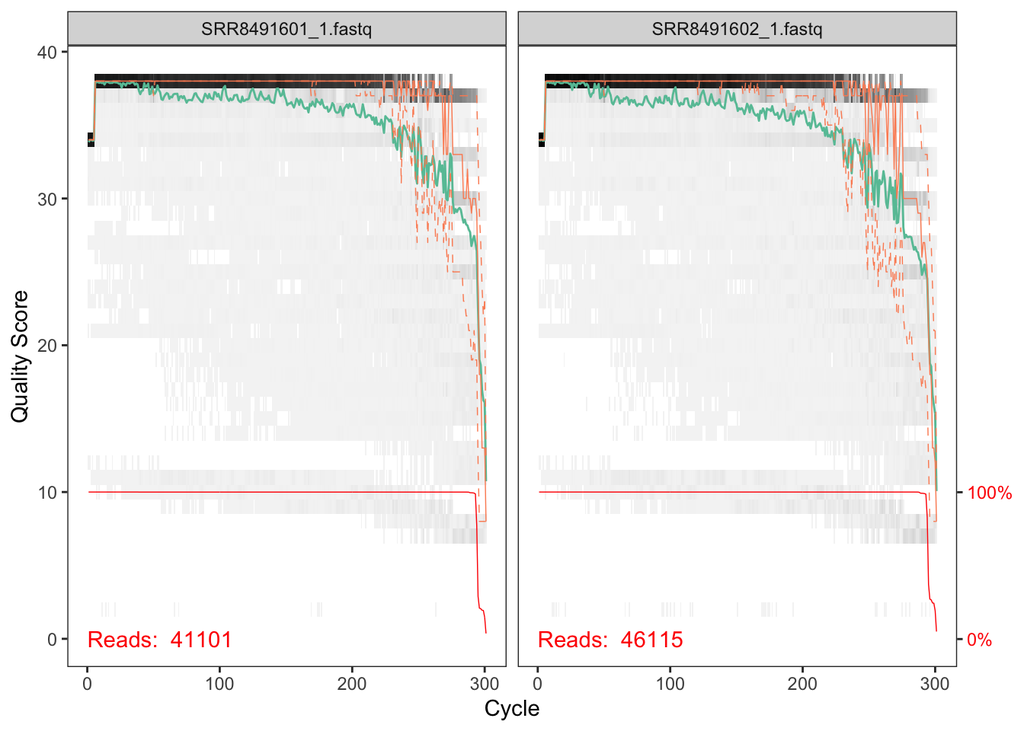

```r
plotQualityProfile(fnFs[1: 2])
```

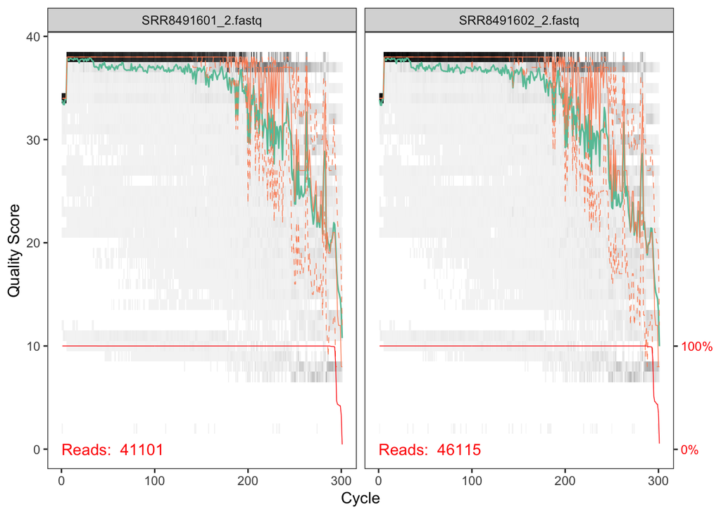

```r
plotQualityProfile(fnRs[1: 2])
```

Extract sample names

```r
sample.names = sapply(strsplit(basename(fnFs), "_"), `[`, 1)
```

Put filtered items in the filtered sub-directory

```r
filt_path = file.path(path, "filtered")
```

Place filtered files in filtered/subdirectory

```r
filtFs = file.path(path, "filtered", paste0(sample.names, "_F_filt.fastq.gz"))
filtRs = file.path(path, "filtered", paste0(sample.names, "_R_filt.fastq.gz"))
```

Filter and trim low-quality sequences

```r
out = filterAndTrim(fnFs, filtFs, fnRs, filtRs, truncLen = c(220,220),
                     maxN = 0, maxEE = c(2,2), truncQ = 2, trimLeft = c(25,20),
                     rm.phix = TRUE, compress = TRUE, multithread = T)
```

```
## Creating output directory: /Users/ngoc/Desktop/coral-bac-rmd/fastq_20files/filtered
```

```r
out1 = as.data.frame(out)
```

```r
#View(out1)
```

## Learn the error rates

Calculating the sequence error rates of reads

```r
errF = learnErrors(filtFs, multithread = T)
```

```
## 102065340 total bases in 523412 reads from 17 samples will be used for learning the error rates.
```

```r
errR = learnErrors(filtRs, multithread = T)
```

```
## 104682400 total bases in 523412 reads from 17 samples will be used for learning the error rates.
```

## Dereplication

Combines all identical sequencing reads into into “unique sequences” with a corresponding “abundance” equal to the number of reads with that unique sequence

```r
derepFs = derepFastq(filtFs, verbose=TRUE)
```

```
## Dereplicating sequence entries in Fastq file: ~/Desktop/coral-bac-rmd/fastq_20files/filtered/SRR8491601_F_filt.fastq.gz
```

```
## Encountered 5215 unique sequences from 37438 total sequences read.
```

```
## Dereplicating sequence entries in Fastq file: ~/Desktop/coral-bac-rmd/fastq_20files/filtered/SRR8491602_F_filt.fastq.gz
```

```
## Encountered 6595 unique sequences from 41564 total sequences read.
```

```
## Dereplicating sequence entries in Fastq file: ~/Desktop/coral-bac-rmd/fastq_20files/filtered/SRR8491603_F_filt.fastq.gz
```

```
## Encountered 8543 unique sequences from 37717 total sequences read.
```

```
## Dereplicating sequence entries in Fastq file: ~/Desktop/coral-bac-rmd/fastq_20files/filtered/SRR8491604_F_filt.fastq.gz
```

```
## Encountered 5688 unique sequences from 35027 total sequences read.
```

```
## Dereplicating sequence entries in Fastq file: ~/Desktop/coral-bac-rmd/fastq_20files/filtered/SRR8491605_F_filt.fastq.gz
```

```
## Encountered 991 unique sequences from 6142 total sequences read.
```

```
## Dereplicating sequence entries in Fastq file: ~/Desktop/coral-bac-rmd/fastq_20files/filtered/SRR8491606_F_filt.fastq.gz
```

```
## Encountered 1734 unique sequences from 13228 total sequences read.
```

```
## Dereplicating sequence entries in Fastq file: ~/Desktop/coral-bac-rmd/fastq_20files/filtered/SRR8491607_F_filt.fastq.gz
```

```
## Encountered 1494 unique sequences from 10198 total sequences read.
```

```
## Dereplicating sequence entries in Fastq file: ~/Desktop/coral-bac-rmd/fastq_20files/filtered/SRR8491608_F_filt.fastq.gz
```

```
## Encountered 1145 unique sequences from 7993 total sequences read.
```

```
## Dereplicating sequence entries in Fastq file: ~/Desktop/coral-bac-rmd/fastq_20files/filtered/SRR8491609_F_filt.fastq.gz
```

```
## Encountered 8815 unique sequences from 37998 total sequences read.
```

```
## Dereplicating sequence entries in Fastq file: ~/Desktop/coral-bac-rmd/fastq_20files/filtered/SRR8491610_F_filt.fastq.gz
```

```
## Encountered 1268 unique sequences from 9520 total sequences read.
```

```
## Dereplicating sequence entries in Fastq file: ~/Desktop/coral-bac-rmd/fastq_20files/filtered/SRR8491611_F_filt.fastq.gz
```

```
## Encountered 10383 unique sequences from 39420 total sequences read.
```

```
## Dereplicating sequence entries in Fastq file: ~/Desktop/coral-bac-rmd/fastq_20files/filtered/SRR8491612_F_filt.fastq.gz
```

```
## Encountered 10618 unique sequences from 49935 total sequences read.
```

```
## Dereplicating sequence entries in Fastq file: ~/Desktop/coral-bac-rmd/fastq_20files/filtered/SRR8491613_F_filt.fastq.gz
```

```
## Encountered 8932 unique sequences from 41336 total sequences read.
```

```
## Dereplicating sequence entries in Fastq file: ~/Desktop/coral-bac-rmd/fastq_20files/filtered/SRR8491614_F_filt.fastq.gz
```

```
## Encountered 9029 unique sequences from 40019 total sequences read.
```

```
## Dereplicating sequence entries in Fastq file: ~/Desktop/coral-bac-rmd/fastq_20files/filtered/SRR8491615_F_filt.fastq.gz
```

```
## Encountered 9267 unique sequences from 42331 total sequences read.
```

```
## Dereplicating sequence entries in Fastq file: ~/Desktop/coral-bac-rmd/fastq_20files/filtered/SRR8491616_F_filt.fastq.gz
```

```
## Encountered 6030 unique sequences from 40442 total sequences read.
```

```
## Dereplicating sequence entries in Fastq file: ~/Desktop/coral-bac-rmd/fastq_20files/filtered/SRR8491617_F_filt.fastq.gz
```

```
## Encountered 4023 unique sequences from 33104 total sequences read.
```

```
## Dereplicating sequence entries in Fastq file: ~/Desktop/coral-bac-rmd/fastq_20files/filtered/SRR8491618_F_filt.fastq.gz
```

```
## Encountered 4279 unique sequences from 45945 total sequences read.
```

```
## Dereplicating sequence entries in Fastq file: ~/Desktop/coral-bac-rmd/fastq_20files/filtered/SRR8491619_F_filt.fastq.gz
```

```
## Encountered 3436 unique sequences from 39709 total sequences read.
```

```
## Dereplicating sequence entries in Fastq file: ~/Desktop/coral-bac-rmd/fastq_20files/filtered/SRR8491620_F_filt.fastq.gz
```

```
## Encountered 3999 unique sequences from 50919 total sequences read.
```

```r
derepRs = derepFastq(filtRs, verbose=TRUE)
```

```
## Dereplicating sequence entries in Fastq file: ~/Desktop/coral-bac-rmd/fastq_20files/filtered/SRR8491601_R_filt.fastq.gz
```

```
## Encountered 6203 unique sequences from 37438 total sequences read.
```

```
## Dereplicating sequence entries in Fastq file: ~/Desktop/coral-bac-rmd/fastq_20files/filtered/SRR8491602_R_filt.fastq.gz
```

```
## Encountered 7252 unique sequences from 41564 total sequences read.
```

```
## Dereplicating sequence entries in Fastq file: ~/Desktop/coral-bac-rmd/fastq_20files/filtered/SRR8491603_R_filt.fastq.gz
```

```
## Encountered 9816 unique sequences from 37717 total sequences read.
```

```
## Dereplicating sequence entries in Fastq file: ~/Desktop/coral-bac-rmd/fastq_20files/filtered/SRR8491604_R_filt.fastq.gz
```

```
## Encountered 6560 unique sequences from 35027 total sequences read.
```

```
## Dereplicating sequence entries in Fastq file: ~/Desktop/coral-bac-rmd/fastq_20files/filtered/SRR8491605_R_filt.fastq.gz
```

```
## Encountered 1381 unique sequences from 6142 total sequences read.
```

```
## Dereplicating sequence entries in Fastq file: ~/Desktop/coral-bac-rmd/fastq_20files/filtered/SRR8491606_R_filt.fastq.gz
```

```
## Encountered 2279 unique sequences from 13228 total sequences read.
```

```
## Dereplicating sequence entries in Fastq file: ~/Desktop/coral-bac-rmd/fastq_20files/filtered/SRR8491607_R_filt.fastq.gz
```

```
## Encountered 1912 unique sequences from 10198 total sequences read.
```

```
## Dereplicating sequence entries in Fastq file: ~/Desktop/coral-bac-rmd/fastq_20files/filtered/SRR8491608_R_filt.fastq.gz
```

```
## Encountered 1556 unique sequences from 7993 total sequences read.
```

```
## Dereplicating sequence entries in Fastq file: ~/Desktop/coral-bac-rmd/fastq_20files/filtered/SRR8491609_R_filt.fastq.gz
```

```
## Encountered 9937 unique sequences from 37998 total sequences read.
```

```
## Dereplicating sequence entries in Fastq file: ~/Desktop/coral-bac-rmd/fastq_20files/filtered/SRR8491610_R_filt.fastq.gz
```

```
## Encountered 1847 unique sequences from 9520 total sequences read.
```

```
## Dereplicating sequence entries in Fastq file: ~/Desktop/coral-bac-rmd/fastq_20files/filtered/SRR8491611_R_filt.fastq.gz
```

```
## Encountered 11780 unique sequences from 39420 total sequences read.
```

```
## Dereplicating sequence entries in Fastq file: ~/Desktop/coral-bac-rmd/fastq_20files/filtered/SRR8491612_R_filt.fastq.gz
```

```
## Encountered 12675 unique sequences from 49935 total sequences read.
```

```
## Dereplicating sequence entries in Fastq file: ~/Desktop/coral-bac-rmd/fastq_20files/filtered/SRR8491613_R_filt.fastq.gz
```

```
## Encountered 10160 unique sequences from 41336 total sequences read.
```

```
## Dereplicating sequence entries in Fastq file: ~/Desktop/coral-bac-rmd/fastq_20files/filtered/SRR8491614_R_filt.fastq.gz
```

```
## Encountered 10587 unique sequences from 40019 total sequences read.
```

```
## Dereplicating sequence entries in Fastq file: ~/Desktop/coral-bac-rmd/fastq_20files/filtered/SRR8491615_R_filt.fastq.gz
```

```
## Encountered 10225 unique sequences from 42331 total sequences read.
```

```
## Dereplicating sequence entries in Fastq file: ~/Desktop/coral-bac-rmd/fastq_20files/filtered/SRR8491616_R_filt.fastq.gz
```

```
## Encountered 7709 unique sequences from 40442 total sequences read.
```

```
## Dereplicating sequence entries in Fastq file: ~/Desktop/coral-bac-rmd/fastq_20files/filtered/SRR8491617_R_filt.fastq.gz
```

```
## Encountered 5507 unique sequences from 33104 total sequences read.
```

```
## Dereplicating sequence entries in Fastq file: ~/Desktop/coral-bac-rmd/fastq_20files/filtered/SRR8491618_R_filt.fastq.gz
```

```
## Encountered 6601 unique sequences from 45945 total sequences read.
```

```
## Dereplicating sequence entries in Fastq file: ~/Desktop/coral-bac-rmd/fastq_20files/filtered/SRR8491619_R_filt.fastq.gz
```

```
## Encountered 6303 unique sequences from 39709 total sequences read.
```

```
## Dereplicating sequence entries in Fastq file: ~/Desktop/coral-bac-rmd/fastq_20files/filtered/SRR8491620_R_filt.fastq.gz
```

```
## Encountered 6475 unique sequences from 50919 total sequences read.
```

Name the derep-class objects by the sample names

```r
names(derepFs) <- sample.names
names(derepRs) <- sample.names
```

## Applying the DADA2 algorithm to the dereplicated data

```r
dadaFs <- dada(derepFs, err=errF, multithread=F)
```

```
## Sample 1 - 37438 reads in 5215 unique sequences.
## Sample 2 - 41564 reads in 6595 unique sequences.
## Sample 3 - 37717 reads in 8543 unique sequences.
## Sample 4 - 35027 reads in 5688 unique sequences.
## Sample 5 - 6142 reads in 991 unique sequences.
## Sample 6 - 13228 reads in 1734 unique sequences.
## Sample 7 - 10198 reads in 1494 unique sequences.
## Sample 8 - 7993 reads in 1145 unique sequences.
## Sample 9 - 37998 reads in 8815 unique sequences.
## Sample 10 - 9520 reads in 1268 unique sequences.
## Sample 11 - 39420 reads in 10383 unique sequences.
## Sample 12 - 49935 reads in 10618 unique sequences.
## Sample 13 - 41336 reads in 8932 unique sequences.
## Sample 14 - 40019 reads in 9029 unique sequences.
## Sample 15 - 42331 reads in 9267 unique sequences.
## Sample 16 - 40442 reads in 6030 unique sequences.
## Sample 17 - 33104 reads in 4023 unique sequences.
## Sample 18 - 45945 reads in 4279 unique sequences.
## Sample 19 - 39709 reads in 3436 unique sequences.
## Sample 20 - 50919 reads in 3999 unique sequences.
```

```r
dadaRs <- dada(derepRs, err=errR, multithread=F)
```

```
## Sample 1 - 37438 reads in 6203 unique sequences.
## Sample 2 - 41564 reads in 7252 unique sequences.
## Sample 3 - 37717 reads in 9816 unique sequences.
## Sample 4 - 35027 reads in 6560 unique sequences.
## Sample 5 - 6142 reads in 1381 unique sequences.
## Sample 6 - 13228 reads in 2279 unique sequences.
## Sample 7 - 10198 reads in 1912 unique sequences.
## Sample 8 - 7993 reads in 1556 unique sequences.
## Sample 9 - 37998 reads in 9937 unique sequences.
## Sample 10 - 9520 reads in 1847 unique sequences.
## Sample 11 - 39420 reads in 11780 unique sequences.
## Sample 12 - 49935 reads in 12675 unique sequences.
## Sample 13 - 41336 reads in 10160 unique sequences.
## Sample 14 - 40019 reads in 10587 unique sequences.
## Sample 15 - 42331 reads in 10225 unique sequences.
## Sample 16 - 40442 reads in 7709 unique sequences.
## Sample 17 - 33104 reads in 5507 unique sequences.
## Sample 18 - 45945 reads in 6601 unique sequences.
## Sample 19 - 39709 reads in 6303 unique sequences.
## Sample 20 - 50919 reads in 6475 unique sequences.
```

Inspecting the returned dada-class object

```r
dadaFs[[1]]
```

```
## dada-class: object describing DADA2 denoising results
## 200 sequence variants were inferred from 5215 input unique sequences.
## Key parameters: OMEGA_A = 1e-40, OMEGA_C = 1e-40, BAND_SIZE = 16
```

## Merging paired data

Merge together the inferred forward and reverse sequences and eliminated the residual errors (non-overlap paired sequences) to construct the ASVs table (ASVs and their abundances).

```r
mergers <- mergePairs(dadaFs, derepFs, dadaRs, derepRs, verbose=TRUE)
```

```
## 35669 paired-reads (in 209 unique pairings) successfully merged out of 36960 (in 739 pairings) input.
```

```
## 39798 paired-reads (in 235 unique pairings) successfully merged out of 41008 (in 788 pairings) input.
```

```
## 32660 paired-reads (in 354 unique pairings) successfully merged out of 36638 (in 1956 pairings) input.
```

```
## 34614 paired-reads (in 108 unique pairings) successfully merged out of 34892 (in 231 pairings) input.
```

```
## 6104 paired-reads (in 19 unique pairings) successfully merged out of 6118 (in 27 pairings) input.
```

```
## 13197 paired-reads (in 21 unique pairings) successfully merged out of 13209 (in 27 pairings) input.
```

```
## 10131 paired-reads (in 28 unique pairings) successfully merged out of 10179 (in 32 pairings) input.
```

```
## 7936 paired-reads (in 16 unique pairings) successfully merged out of 7971 (in 23 pairings) input.
```

```
## 33420 paired-reads (in 339 unique pairings) successfully merged out of 37128 (in 1745 pairings) input.
```

```
## 9451 paired-reads (in 9 unique pairings) successfully merged out of 9451 (in 9 pairings) input.
```

```
## 32757 paired-reads (in 384 unique pairings) successfully merged out of 37821 (in 2596 pairings) input.
```

```
## 45638 paired-reads (in 413 unique pairings) successfully merged out of 48758 (in 1944 pairings) input.
```

```
## 37677 paired-reads (in 348 unique pairings) successfully merged out of 40318 (in 1522 pairings) input.
```

```
## 35787 paired-reads (in 332 unique pairings) successfully merged out of 38832 (in 1604 pairings) input.
```

```
## 38418 paired-reads (in 337 unique pairings) successfully merged out of 41414 (in 1598 pairings) input.
```

```
## 40072 paired-reads (in 84 unique pairings) successfully merged out of 40292 (in 161 pairings) input.
```

```
## 32861 paired-reads (in 97 unique pairings) successfully merged out of 32998 (in 124 pairings) input.
```

```
## 45812 paired-reads (in 115 unique pairings) successfully merged out of 45914 (in 156 pairings) input.
```

```
## 39467 paired-reads (in 103 unique pairings) successfully merged out of 39631 (in 155 pairings) input.
```

```
## 50709 paired-reads (in 74 unique pairings) successfully merged out of 50867 (in 118 pairings) input.
```

```r
head(mergers[[1]])
```

```
##                                                                                                                                                                                                                                                     sequence
## 1  GCCGTAAACGATGTCTACTAGCCGTTGGGGAACTTGATTCTTTAGTGGCGCAGCTAACGC…
## 2  GCCGTAAACGATGTCTACTAGCCGTTGGGGAACTTGATTCTTTAGTGGCGCAGCTAACGC…
## 3  GCCGTAAACGATGTCAACTAGCCGTTGGGGAACTTGATTCTTTAGTGGCGCAGCTAACGC…
## 4   GCCCTAAACGATGTCAACTAGGTGTATGGAATGAATTTTCTGTGTATCGAAGCTAACGCG…
## 5 GCCGTAAACGATGTCTACTAGTCGTTGGGAATCTTAGTATTCTTGGTGACGAAGTTAACG…
## 6   ACCGTAAACGATGAATGCCAGTCGTCGGGTAGCATGCTATTCGGTGACACACCTAACGGA…
##   abundance forward reverse nmatch nmismatch nindel prefer accept
## 1     11413       1       1    146         0      0      1   TRUE
## 2      3489       3       2    146         0      0      1   TRUE
## 3      2878       4       3    146         0      0      1   TRUE
## 4      2527       5       4    147         0      0      1   TRUE
## 5      2369       6       5    145         0      0      1   TRUE
## 6      1631       2       6    147         0      0      1   TRUE
```

## Constructing ASV table

```r
seqtab <- makeSequenceTable(mergers)
```

Remove chimeras

```r
seqtab.nochim <- removeBimeraDenovo(seqtab, method="consensus", multithread=TRUE, verbose=TRUE)
```

```
## Identified 652 bimeras out of 1492 input sequences.
```

```r
dim(seqtab.nochim)
```

```
## [1]  20 840
```

Calculate the percentage of remained sequences after removing chimera

```r
sum(seqtab.nochim)/sum(seqtab)
```

```
## [1] 0.9568403
```

## Taxonomy assignment

Download training data sets at https://zenodo.org/record/4587955#.YlecbchBy00

Assign taxonomy to genus level

```r
taxaRC <- assignTaxonomy(seqtab.nochim, "~/Desktop/coral-bac-rmd/silva_nr99_v138.1_train_set.fa", tryRC=TRUE, multithread = T)
```

Assign taxonomy to species level

```r
taxaSp <- addSpecies(taxaRC, "~/Desktop/coral-bac-rmd/silva_species_assignment_v138.1.fa")
```

Inspecting taxonomy assignment

```r
taxaRC_print = taxaRC
rownames(taxaRC_print) = NULL # remove sequence row names for display
class(taxaRC) # matrix, array
```

```
## [1] "matrix" "array"
```

```r
df_taxaRC = as.data.frame(taxaRC_print) # convert to data frame
```

```r
taxaSp_print = taxaSp
rownames(taxaSp_print) = NULL
df_taxaSp = as.data.frame(taxaSp_print)
```

### TABLE 2

```r
#View(df_taxaSp)
head(df_taxaSp)
```

```
##    Kingdom         Phylum               Class           Order
## 1 Bacteria Proteobacteria Gammaproteobacteria Pseudomonadales
## 2 Bacteria Proteobacteria Gammaproteobacteria Burkholderiales
## 3 Bacteria Proteobacteria Gammaproteobacteria Pseudomonadales
## 4 Bacteria Proteobacteria Gammaproteobacteria Pseudomonadales
## 5 Bacteria Proteobacteria Gammaproteobacteria Pseudomonadales
## 6 Bacteria Proteobacteria Gammaproteobacteria Burkholderiales
##                Family                                      Genus Species
## 1                <NA>                                       <NA>    <NA>
## 2    Burkholderiaceae Burkholderia-Caballeronia-Paraburkholderia    <NA>
## 3  Spongiibacteraceae                               Litorivivens    <NA>
## 4 Endozoicomonadaceae                             Endozoicomonas    <NA>
## 5 Endozoicomonadaceae                             Endozoicomonas    <NA>
## 6    Burkholderiaceae                                  Ralstonia    <NA>
```

## Microbiome analysis

Contruct a sample data frame (data table) of the information above

```r
samples.out <- rownames(seqtab.nochim)
subject <- sapply(strsplit(samples.out, "D"), `[`, 1)
gender <- substr(subject,1,1)
subject <- substr(subject,2,999)
day <- as.integer(sapply(strsplit(samples.out, "D"), `[`, 2))
samdf <- data.frame(Subject=subject, Gender=gender, Day=day)
samdf$When <- "Early"
samdf$When[samdf$Day>100] <- "Late"
rownames(samdf) <- samples.out
```

Combine the ASVs table, taxonomic table and sample data table into phyloseq object

```r
ps <- phyloseq(otu_table(seqtab.nochim,taxa_are_rows=FALSE), tax_table(taxaSp), sample_data(samdf))
```

Filtering phyloseq objects at the “Phylum” level, return a data frame

```r
Bacphy = ps%>%
  tax_glom(taxrank = "Phylum")%>% # agglomerate data of the same phylum
  transform_sample_counts(function(x) {x/sum(x)})%>% # convert to a diversity analysis object
  psmelt()%>% # combine format(?), melt and merge all into a data frame
  filter(Abundance > 0.02)%>% # filter out low diversity taxa
  arrange(Phylum) # arrange data frame alphabetically by phylum
```

Filtering phyloseq objects at the “Class” level, return a data frame

```r
Bacclass = ps%>%
  tax_glom(taxrank = "Class")%>%
  transform_sample_counts(function(x) {x/sum(x)})%>%
  psmelt()%>%
  filter(Abundance > 0.02)%>%
  arrange(Class)
```

Filtering phyloseq objects at the “Genus” level, return a data frame

```r
Bacgenus = ps%>%
  tax_glom(taxrank = "Genus")%>%
  transform_sample_counts(function(x) {x/sum(x)})%>%
  psmelt()%>%
  filter(Abundance > 0.02)%>%
  arrange(Genus)
```

## Visualization

### Phylum Composition - FIGURE 1A

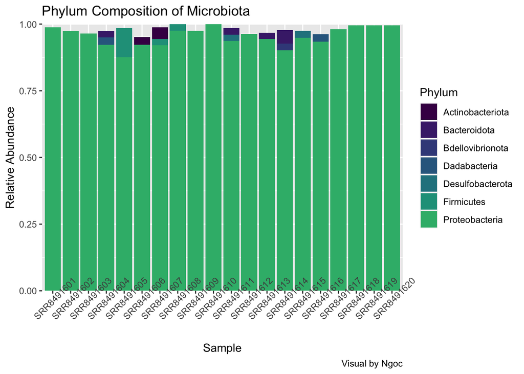

```r
ggplot(data = Bacphy, aes(x = Sample, y = Abundance, fill = Phylum)) +
  geom_bar(stat = "identity") +
  scale_fill_manual(values = viridis(10)) + # fill color
  ylab("Relative Abundance") + # assign y axis name
  scale_y_continuous(expand = c(0,0)) + # clear space below 0 on y-axis
  labs(title = "Phylum Composition of Microbiota", caption = "Visual by Ngoc") +
  theme(axis.text.x = element_text(angle = 45))
```

### Class Composition - FIGURE 1B

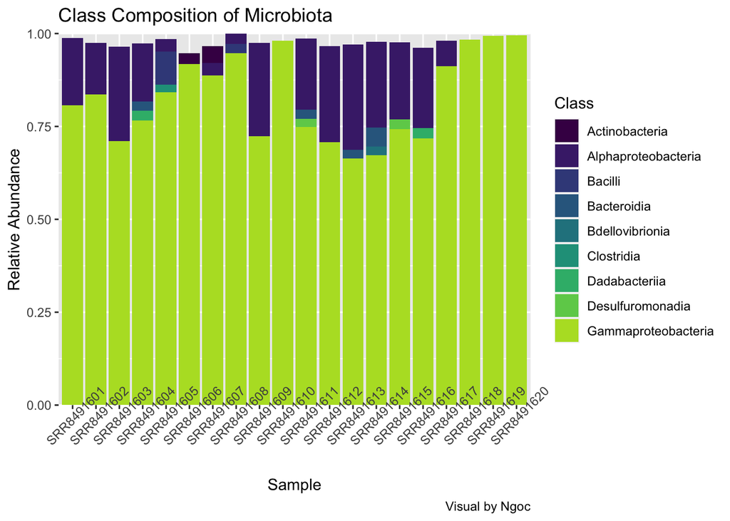

```r
ggplot(data = Bacclass, aes(x = Sample, y = Abundance, fill = Class)) +
  geom_bar(stat = "identity") +
  scale_fill_manual(values = viridis(10)) +
  ylab("Relative Abundance") +
  scale_y_continuous(expand = c(0,0)) +
  labs(title = "Class Composition of Microbiota", caption = "Visual by Ngoc") +
  theme(axis.text.x = element_text(angle = 45))
```

### Genus Composition - FIGURE 2

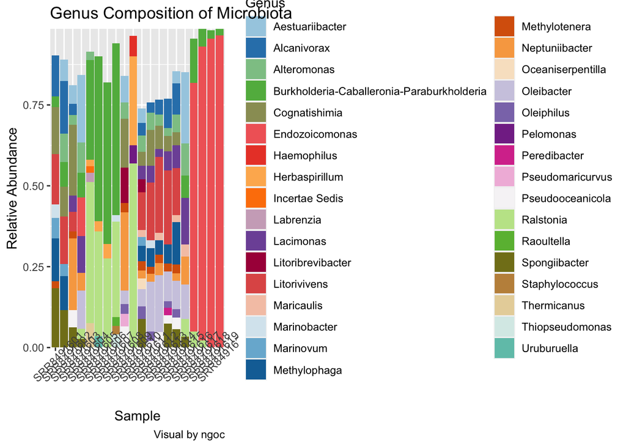

```r
pal = c(brewer.pal(10, "Paired"), brewer.pal(5, "RdBu"),
        brewer.pal(5, "PuOr"), brewer.pal(5, "PiYG"),
        brewer.pal(5, "BrBG")) # this is apparently not the best color palatte choice
mycolors <- colorRampPalette(pal)(34)
ggplot(data = Bacgenus, aes(x = Sample, y = Abundance, fill = Genus)) +
  geom_bar(stat = "identity") +
  scale_fill_manual(values = mycolors) +
  ylab('Relative Abundance') +
  scale_y_continuous(expand = c(0,0)) +
  labs(title = "Genus Composition of Microbiota", caption = "Visual by ngoc")+
  theme(axis.text.x = element_text(angle = 45))
```

## Treemap

### Classification levels of Class and Order - FIGURE 3A

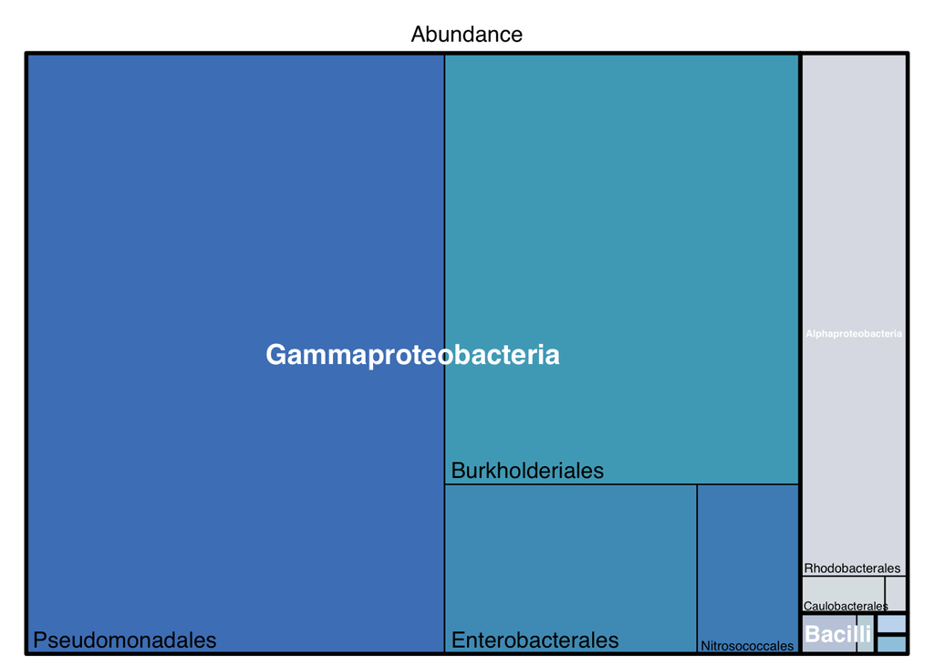

```r
treemap(Bacgenus, index = c("Class", "Order"),
        vSize = "Abundance", type = "index",
        fontsize.labels = c(15,12),
        fontcolor.labels = c("white", "black"),
        fontface.labels = c(2,1), #1,2,3,4: lower, bold, italic, bold_italic
        bg.labels = "transparent", # background color of labels
        align.labels = list(c("center", "center"), c("left", "bottom")),
        overlap.labels = 0.5, # tolerance for overlap between labels
        inflate.labels = F, # if true, the label is larger if rectangle is larger,
        fontsize.title = 12,
        palette = "Blues")
```

### Classification levels of Family and Genus - FIGURE 3B

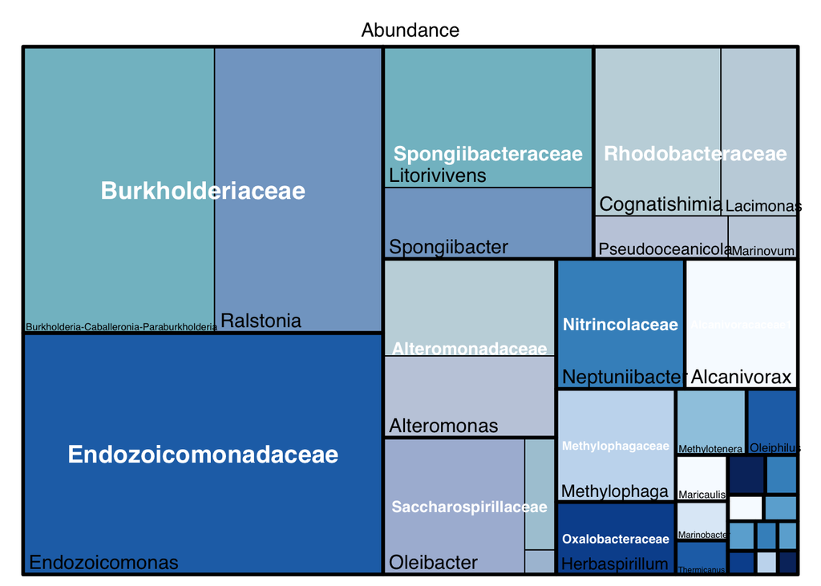

```r
treemap(Bacgenus, index = c("Family", "Genus"),
        vSize = "Abundance", type = "index",
        fontsize.labels = c(15,12),
        fontcolor.labels = c("white", "black"),
        fontface.labels = c(2,1), #1,2,3,4: lower, bold, italic, bold_italic
        bg.labels = "transparent", # background color of labels
        align.labels = list(c("center", "center"), c("left", "bottom")),
        overlap.labels = 0.5, # tolerance for overlap between labels
        inflate.labels = F, # if true, the label is larger if rectangle is larger,
        fontsize.title = 12,
        palette = "Blues")
```